# Whose ideas are worth spreading? The representation of women and ethnic groups in TED talks - A Small Replication using R

## Analysis

### (Structural) Topic Model

Our text data is now prepared. Before we can fit the actual STM we have to consider that each topic model implementation in R (e.g., LDA, biterm topic model, structural topic models) needs a different input format. The stm-package which I will use in the following needs a different format than the quanteda object we just designed $\rightarrow$ use the {quanteda}-convert function to construct such an object.

```r
out <- convert(ted_dfm, to = "stm", docvars=df)

str(out, max.level = 1)
```

```
## List of 3
##  $ documents:List of 2333
##  $ vocab    : chr [1:4805] "$" "♫" "10th" "15-year-old" ...
##  $ meta     : tibble[,6] [2,333 x 6] (S3: tbl_df/tbl/data.frame)
```

Now, using this object containing all 2333 documents and their respective vocabulary we can perform our first topic model.

```r
# running model with 20 topics with covariates
stm_20 <- stm(
  documents=out$documents,
  vocab=out$vocab,
  data = out$meta,
  prevalence =  ~ s(date_num, degree = 2) + dummy_female * dummy_white,
  init.type = 'Spectral', #default
  K = 20,
  verbose = FALSE
)
```

We can also plot the results of our topic model.

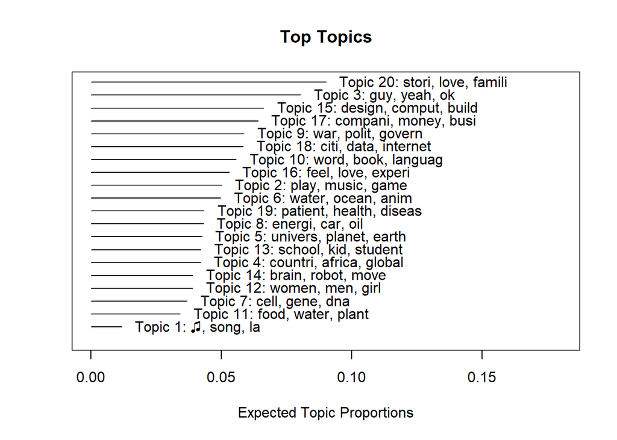

```r
# plot topics with most frequent words within topics
plot(stm_20)
```

```r
# By using summary() you receive top words for all 20 topics
summary(stm_20)
```

```
## A topic model with 20 topics, 2333 documents and a 4805 word dictionary.
```

```
## Topic 1 Top Words:
##       Highest Prob: ♫, song, la, sing, oh, love, feel
##       FREX: ♫, la, song, sing, loop, oh, sheep
##       Lift: ♫, la, song, sing, coke, ski, ooh
##       Score: ♫, song, la, sing, music, ooh, feminist
## Topic 2 Top Words:
##       Highest Prob: play, music, game, sound, art, film, artist
##       FREX: artist, music, film, art, paint, game, play
##       Lift: jersey, orchestra, cinema, opera, musician, music, masterpiec
##       Score: jersey, music, art, film, paint, artist, game
## Topic 3 Top Words:
##       Highest Prob: guy, yeah, ok, oh, stuff, sort, mayb
##       FREX: guy, ok, yeah, stuff, oh, card, ca
##       Lift: da, nerd, comedi, dude, yeah, guy, ok
##       Score: da, ok, stuff, guy, ca, yeah, oh
## Topic 4 Top Words:
##       Highest Prob: countri, africa, global, china, india, develop, state
##       FREX: china, africa, india, chines, african, aid, countri
##       Lift: curtain, ghana, capita, shanghai, sub-saharan, china, export
##       Score: curtain, countri, africa, india, china, economi, chines
## Topic 5 Top Words:
##       Highest Prob: univers, planet, earth, space, light, star, scienc
##       FREX: galaxi, mar, particl, telescop, star, mathemat, orbit
##       Lift: galaxi, hover, astronomi, spacecraft, telescop, asteroid, orbit
##       Score: galaxi, telescop, particl, hover, mar, orbit, quantum
## Topic 6 Top Words:
##       Highest Prob: water, ocean, anim, fish, tree, sea, forest
##       FREX: ocean, forest, shark, sea, whale, coral, ice
##       Lift: iceberg, reef, glacier, underwat, expedit, forest, canopi
##       Score: iceberg, coral, ocean, forest, shark, speci, reef
## Topic 7 Top Words:
##       Highest Prob: cell, gene, dna, bodi, biolog, organ, genet
##       FREX: dna, gene, genom, cell, genet, tissu, molecul
##       Lift: silk, chromosom, genom, dna, bacteri, mutat, tissu
##       Score: silk, gene, cell, genom, dna, bacteria, tissu
## Topic 8 Top Words:
##       Highest Prob: energi, car, oil, power, electr, percent, technolog
##       FREX: oil, energi, car, fuel, nuclear, vehicl, electr
##       Lift: fusion, emiss, coal, watt, brake, congest, renew
##       Score: fusion, climat, co2, solar, carbon, energi, car
```

[output cut: 45 more lines]

```
## Topic 18 Top Words:
##       Highest Prob: citi, data, internet, inform, network, build, connect
##       FREX: internet, citi, network, onlin, web, twitter, facebook
##       Lift: tedtalk, wikipedia, twitter, browser, upload, privaci, blogger
##       Score: tedtalk, citi, data, twitter, inform, internet, web
## Topic 19 Top Words:
##       Highest Prob: patient, health, diseas, cancer, medic, drug, doctor
##       FREX: patient, medic, clinic, doctor, treatment, surgeri, hospit
##       Lift: tom, physician, surgeri, medic, clinic, patient, cardiac
##       Score: tom, patient, cancer, drug, diseas, health, medic
## Topic 20 Top Words:
##       Highest Prob: stori, love, famili, walk, feel, home, man
##       FREX: father, felt, son, knew, dad, walk, night
##       Lift: mama, goodby, closet, grandfath, ash, homeless, fled
##       Score: mama, father, famili, girl, dad, interview, love
```

The huge advantage of STM above other topic model implementations in R is that we can include covariates to examine influences of those on topic prevelance. Such research questions are extremely interesting for description as well as explanation within social scientific research questions (*e.g., are women more likely to talk about technical topics than men?*).

Here I only use the summary() function to display regression coefficients for each topic. This however results in 20 rather long tables, which we shouldn’t report in this way.

The original paper contains some [great plots](https://dataverse.harvard.edu/file.xhtml?persistentId=doi:10.7910/DVN/EUDWP3/MCZREF&version=2.0) that visualizes findings from the regression analysis.

```r
# fit regression of topic prevalence on gender and ethnicity
effect_stm_20 <- estimateEffect(1:20 ~ s(date_num, degree = 2) +
                                  dummy_female * dummy_white,
                 stm_20,
                 metadata = out$meta)

#summary() gives you regression coefficients for all 20 topics
#summary(effect_stm_20)
```

## Validation and Model Selection

### The optimal number of k

This far, we simply decided to set k (= the number of topics) to 20, i.e. we expect our selection of TED talks to cover 20 topics. This was pure guessing. There are many different ways of how to specify k (informed guessing via theory and previous research, [rule of thumb](https://cran.r-project.org/web/packages/stm/stm.pdf), manual labeling of a subset, **statistical measures**).

In the following, we will focus on statistical measures, which is a comparatively fast and reasonable way of validating your **k**. To do so:

1. perform multiple topic models with multiple specifications of k
2. compare those on basis of statistical measures
3. choose one specification of k
4. finally visualizise and manual interpretate your topic model of choice

```r
# specify models with different k
stm_20_30_40_50 <- tibble(K = c(20, 30, 40, 50)) %>%
  mutate(model = map(K, ~ stm(out$documents,
                              out$vocab,
                              data=out$meta,
                              prevalence =  ~ s(date_num, degree = 2) +
                                dummy_female * dummy_white,
                              K = .,
                              verbose = FALSE)))
stm_20_30_40_50

#took about 20 min on my PC
```

```r
#extract objects for single k values to perform regression and other analysis
stm20<-stm_20_30_40_50[[1,2]]
stm30<-stm_20_30_40_50[[2,2]]
stm40<-stm_20_30_40_50[[3,2]]
stm50<-stm_20_30_40_50[[4,2]]
```

```r
stm50
```

```
## [[1]]
## A topic model with 50 topics, 2333 documents and a 4805 word dictionary.
```

### Semantic Coherence and Exclusivity

There is a variety of statistical measures to evaluate your model, see for instance [here](https://juliasilge.com/blog/evaluating-stm/).

- **Semantic coherence**: how often do terms that have a high probability of belonging to one topic, also co-occur in the respective document?
- However, do not only consider semantic coherence (can easily be improved by simply modeling fewer topels) but also consider exclusivity
- **Exclusivity**: How exclusive are the terms that occur with high probability for a topic; put differently: are they for other topics very unlikely?

In my opinion most insights are generated by plotting the two measures against each other:

**Short Interpretation?** The higher the semantic coherence and the higher the exclusivity of words within a topic, the “better” a topic model.

```r
# calculate exclusivity + semantic coherence
model_scores <- stm_20_30_40_50 %>%
  mutate(exclusivity = map(model, exclusivity),
         semantic_coherence = map(model, semanticCoherence, out$documents)) %>%
  select(K, exclusivity, semantic_coherence)

model_scores #results in nested dataframes containing the quantities of interest
```

```
## # A tibble: 4 x 3
##       K exclusivity semantic_coherence
##   <dbl> <list>      <list>
## 1    20 <dbl [20]>  <dbl [20]>
## 2    30 <dbl [30]>  <dbl [30]>
## 3    40 <dbl [40]>  <dbl [40]>
## 4    50 <dbl [50]>  <dbl [50]>
```

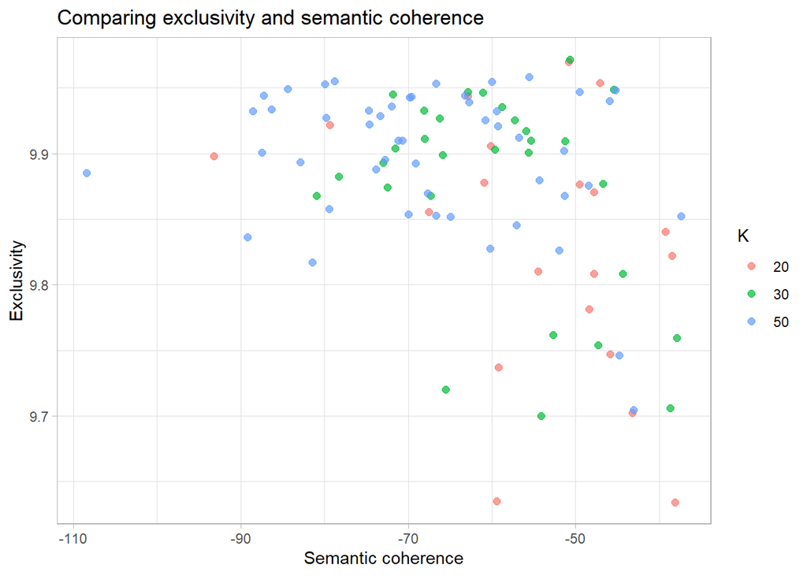

```r
# plot
model_scores %>%
  select(K, exclusivity, semantic_coherence) %>%
  filter(K %in% c(20, 30, 50)) %>%
  unnest() %>%
  mutate(K = as.factor(K)) %>%
  ggplot(aes(semantic_coherence, exclusivity, color = K)) +
  geom_point(size = 2, alpha = 0.7) +
  labs(x = "Semantic coherence",
       y = "Exclusivity",
       title = "Comparing exclusivity and semantic coherence")
```

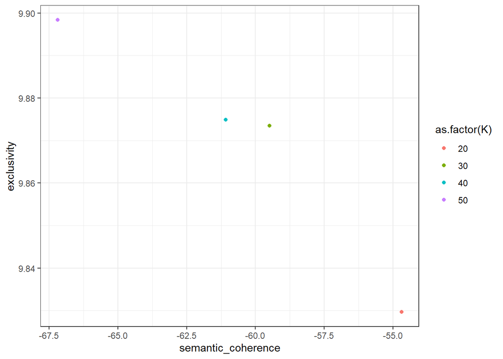

```r
# upper right area shows "good" topic model specifications

# plot means for better overview
model_scores %>%
  unnest(c(exclusivity, semantic_coherence)) %>%
  group_by(K) %>%
  summarize(exclusivity = mean(exclusivity),
            semantic_coherence = mean(semantic_coherence)) %>%
  ggplot(aes(x = semantic_coherence, y = exclusivity, color = as.factor(K))) +
  geom_point() +
  theme_bw()
```

### TED Talks contain 30 topics!

## Visualization and Model Interpretation

After inspecting the different topic models, we found that the model with 30 topics includes the most useful topics for our analysis.

Now let’s see what this topic model tells us about the Ted Talk Corpus and our research questions.

### Highest word probabilities for each topic

In order to gain valuable insights into the topics found and to be able to make nice visualizations, I would recommend using ggplot2.

To do so, first, we have to transform our stm-object to a ggplot2- and tidyverse compatible format using the {tidytext}-package.

```r
td_beta <- tidy(stm30[[1]])
td_beta
```

```
## # A tibble: 144,150 x 3
##    topic term      beta
##    <int> <chr>    <dbl>
##  1     1 $     2.48e-81
##  2     2 $     1.08e- 5
##  3     3 $     5.24e-12
##  4     4 $     4.29e- 4
##  5     5 $     9.85e-23
##  6     6 $     4.21e-27
##  7     7 $     4.56e-11
##  8     8 $     1.90e- 4
##  9     9 $     4.49e-20
## 10    10 $     1.40e-21
## # ... with 144,140 more rows
```

One good idea is to plot the most likely words per topic. For this we have to extract the beta values from out topic model (beta is the probability of words belonging to topics) and perform some ggplot coding.

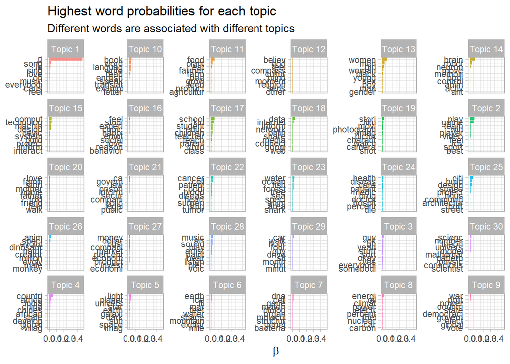

```r
td_beta %>%
    group_by(topic) %>%
    top_n(10, beta) %>%
    ungroup() %>%
    mutate(topic = paste0("Topic ", topic),
           term = reorder_within(term, beta, topic)) %>%
    ggplot(aes(term, beta, fill = as.factor(topic))) +
    geom_col(alpha = 0.8, show.legend = FALSE) +
    facet_wrap(~ topic, scales = "free_y") +
    coord_flip() +
    scale_x_reordered() +
    labs(x = NULL, y = expression(beta),
         title = "Highest word probabilities for each topic",
         subtitle = "Different words are associated with different topics")
```

Unfortunately, with this high number of topics (remember, k is set to 30 here), the small multiples get quite small. Maybe consider to use a shiny app to explore all your topics. For an demonstration see [here](https://juliasilge.shinyapps.io/sherlock-holmes/#section-words-by-topic).

### Top words per topic

```r
# By using summary() you receive top words for all 20 topics
summary(stm30[[1]])
```

```
## A topic model with 30 topics, 2333 documents and a 4805 word dictionary.
```

```
## Topic 1 Top Words:
##       Highest Prob: ♫, song, la, sing, love, oh, music
##       FREX: ♫, la, song, sing, loop, gonna, ooh
##       Lift: ♫, la, song, sing, coke, ooh, ski
##       Score: ♫, song, la, sing, ooh, poem, music
## Topic 2 Top Words:
##       Highest Prob: play, game, team, win, player, video, feel
##       FREX: game, player, win, toy, athlet, play, sport
##       Lift: jersey, championship, game, athlet, basebal, player, olymp
##       Score: game, jersey, play, player, coach, athlet, toy
## Topic 3 Top Words:
##       Highest Prob: guy, ok, oh, yeah, stuff, sort, okay
##       FREX: ok, yeah, oh, guy, okay, stuff, ted
##       Lift: da, ok, yeah, oh, uh, um, dude
##       Score: da, ok, yeah, oh, stuff, card, guy
## Topic 4 Top Words:
##       Highest Prob: countri, africa, india, china, chines, african, state
##       FREX: india, africa, china, african, chines, indian, villag
##       Lift: curtain, ghana, india, nigeria, africa, african, china
##       Score: curtain, africa, countri, india, china, african, chines
## Topic 5 Top Words:
##       Highest Prob: light, planet, univers, star, earth, galaxi, dark
##       FREX: galaxi, star, telescop, light, sun, dark, planet
##       Lift: galaxi, hover, wavelength, astronomi, asteroid, telescop, jupit
##       Score: galaxi, telescop, hover, planet, solar, asteroid, orbit
## Topic 6 Top Words:
##       Highest Prob: earth, ice, fli, mar, feet, water, space
##       FREX: ice, mar, pole, feet, cave, satellit, mountain
##       Lift: iceberg, glacier, volcano, altitud, antarctica, ice, pole
##       Score: iceberg, mar, ice, glacier, satellit, expedit, pole
## Topic 7 Top Words:
##       Highest Prob: dna, cell, gene, materi, biolog, organ, molecul
##       FREX: dna, genom, molecul, bacteria, gene, genet, sequenc
##       Lift: silk, chromosom, genom, spider, microb, bacteria, mushroom
##       Score: silk, bacteria, genom, gene, molecul, dna, microb
## Topic 8 Top Words:
##       Highest Prob: energi, oil, climat, power, electr, percent, fuel
##       FREX: oil, energi, fuel, nuclear, climat, electr, emiss
##       Lift: fusion, coal, emiss, co2, watt, renew, fuel
##       Score: fusion, climat, co2, carbon, solar, energi, emiss
```

[output cut: 95 more lines]

```
## Topic 28 Top Words:
##       Highest Prob: music, art, sound, play, artist, paint, hear
##       FREX: art, artist, music, paint, sound, musician, piano
##       Lift: violin, orchestra, piano, musician, music, artist, artwork
##       Score: violin, music, art, artist, paint, museum, sculptur
## Topic 29 Top Words:
##       Highest Prob: car, walk, hour, four, guy, drive, sit
##       FREX: car, morn, driver, seat, shoe, crash, drive
##       Lift: jam, hobbi, pad, car, taxi, crash, candi
##       Score: jam, car, driver, leg, lane, seat, ride
## Topic 30 Top Words:
##       Highest Prob: scienc, number, theori, univers, model, mathemat, pattern
##       FREX: theori, mathemat, particl, scienc, conscious, quantum, pattern
##       Lift: symmetri, mathematician, quantum, mathemat, newton, theori, particl
##       Score: symmetri, particl, quantum, mathemat, scienc, mathematician, theori
```

### One final plot

… originally from [Julia Silge](https://juliasilge.com/blog/evaluating-stm/) 👍

[figure not shown]

```r
td_gamma <- tidy(stm30[[1]], matrix = "gamma",
                 document_names = rownames(ted_dfm))

top_terms <- td_beta %>%
  arrange(beta) %>%
  group_by(topic) %>%
  top_n(7, beta) %>%
  arrange(-beta) %>%
  select(topic, term) %>%
  summarise(terms = list(term)) %>%
  mutate(terms = map(terms, paste, collapse = ", ")) %>%
  unnest()

gamma_terms <- td_gamma %>%
  group_by(topic) %>%
  summarise(gamma = mean(gamma)) %>%
  arrange(desc(gamma)) %>%
  left_join(top_terms, by = "topic") %>%
  mutate(topic = paste0("Topic ", topic),
         topic = reorder(topic, gamma))

gamma_terms %>%
  top_n(20, gamma) %>%
  ggplot(aes(topic, gamma, label = terms, fill = topic)) +
  geom_col(show.legend = FALSE) +
  geom_text(hjust = 0, nudge_y = 0.0005, size = 3,
            family = "IBMPlexSans") +
  coord_flip() +
  scale_y_continuous(expand = c(0,0),
                     limits = c(0, 0.09),
                     labels = percent_format()) +
  theme_tufte(base_family = "IBMPlexSans", ticks = FALSE) +
  theme(plot.title = element_text(size = 16,
                                  family="IBMPlexSans-Bold"),
        plot.subtitle = element_text(size = 13)) +
  labs(x = NULL, y = expression(gamma),
       title = "Top 30 topics by prevalence in the TED Talks corpus",
       subtitle = "With the top words that contribute to each topic")
```